# Project 07: Burrows-Wheeler Transform

# Pattern Matching with BWT

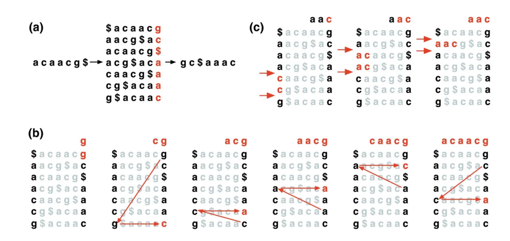

> Credit: [“DNA Sequence Alignment with the Burrows Wheeler Transform”](https://cs.carleton.edu/cs_comps/2324/sequenceAlignment/) from Carleton College

## Alignments using BWT

With the BWT and auxiliary structures in place, we can efficiently find pattern matches using backward search:

> $${\small
> \begin{array}{l}
> \textbf{function } \text{update_range}(\text{character}, \text{range
> start}, \text{range end}, \text{counts}, \text{occurrences}) \\
> \quad \text{Calculate new start position using character's count and
> occurrences at range start} \\
> \quad \text{Calculate new end position using character's count and
> occurrences at range end} \\
> \quad \textbf{return } \text{new start and end positions}
> \end{array}
> }$$

```python
def update_range(
  lower: int,
  upper: int,
  count: dict[str, int],
  occur: dict[str, list[int]],
  a: str) -> tuple[int, int]:
    """Function to update range given character a.

    Updates the search range during backward search in the BWT pattern matching
    algorithm when processing character a.

    Args:
        lower: The lower boundary of the current range.
        upper: The upper boundary of the current range.
        count: Dictionary mapping each character to the count of lexicographically
            smaller characters.
        occur: Dictionary mapping each character to its occurrence counts at each
            position.
        a: The character being processed in the pattern.

    Returns:
        A tuple containing the updated lower and upper boundaries of the range.

    Note:
        This function assumes occur[a][-1] = 0 for boundary conditions.
    """
    pass
```

> $${\small
> \begin{array}{l}
> \textbf{function } \text{find_match}(\text{pattern}, \text{transformed},
> \text{counts}, \text{occurrences}, \text{suffix positions}) \\
> \quad \text{Initialize search range to cover the entire transformed
> text} \\
> \quad \textbf{for each } \text{character in the pattern, processing from
> right to left} \textbf{ do} \\
> \quad\quad \text{Update the search range based on the current character}
> \\
> \quad\quad \textbf{if } \text{the range becomes empty} \textbf{ then} \\
> \quad\quad\quad \textbf{return } \text{empty list as pattern is not
> found} \\
> \quad \text{Collect all suffix positions within the final range} \\
> \quad \textbf{return } \text{the list of matching positions}
> \end{array}
> }$$

```python
def find_match(query: str, reference: str) -> list[int]:
    """Function to find exact matching by applying Burrows-Wheeler Transform.

    Searches for all occurrences of the query string within the reference string
    using the Burrows-Wheeler Transform algorithm for efficient pattern matching.

    Args:
        query: The pattern string to search for.
        reference: The text string to search within.

    Returns:
        A list of integers representing the 0-based starting positions of all
        occurrences of the query string within the reference string. Returns an
        empty list if no matches are found.

    Examples:
        >>> find_match('ana', 'banana')
        [1, 3]

        >>> find_match('xyz', 'banana')
        []
    """
    pass
```

## Tricky Parts to Watch Out For

1. **End-of-string character**: Ensure your implementation includes a unique end-of-string character (often ‘$’) that doesn’t appear elsewhere in the string. This character should typically be lexicographically smaller than all other characters.
2. **Indexing issues**: Pay careful attention to zero-based versus one-based indexing, especially when implementing the BWT from suffix arrays.
3. **Edge cases**: Handle edge cases properly, such as when the suffix array index is 0, or when dealing with empty strings or patterns.
4. **Performance considerations**: The naive BWT implementation is $O(n^2 \log n)$ due to sorting n strings of length n. Using suffix arrays reduces this to $O(n \log n)$.
5. **Memory usage**: For large strings, storing all rotations can be memory-intensive. The suffix array approach is more memory-efficient.

# Summary

The Burrows-Wheeler Transform showcases how a seemingly simple reordering of characters can lead to powerful applications in compression and pattern matching. By understanding both the conceptual foundation and the implementation details, you’ll gain insight into one of the most elegant algorithms in computer science, with applications ranging from everyday file compression to cutting-edge genomic research.